# Yifan_Wu

Yifan Wu

February 11, 2018

# 3.7.3

## (a). Which answer is correct, and why?

The linear regression model is of the following form:

$$Salary = 50 +20GPA+0.07IQ+35Gender+0.01GPA*IQ-10GPA*Gender$$

For males:

$$Salary = 50 +20GPA+0.07IQ+0.01GPA*IQ$$

For Females:
$$Salary = 85 + 10 GPA + 0.07IQ + 0.01GPA*IQ$$

Assume male earn more than female, that is:

$$50 + 20GPA > 85 + 10 GPA \Rightarrow GPA > 3.5$$

This is a high GPA, so (iii) is correct.

## (b).

We plug in $IQ=110$ and $GPA=4$, we get $Salary = 137.1$.

## (c).

False, There is not enough evidence to say that there is no intercation between GPA and IQ. We need to test the hypothesis that $\beta_{4} = 0$ and get the p-value and the F statistics to determine if the coefficient is significant.

# 3.7.9.

## (e).

```r
library(ISLR)

cor(Auto[1:8])
```

```
##                     mpg  cylinders displacement horsepower     weight
## mpg           1.0000000 -0.7776175   -0.8051269 -0.7784268 -0.8322442
## cylinders    -0.7776175  1.0000000    0.9508233  0.8429834  0.8975273
## displacement -0.8051269  0.9508233    1.0000000  0.8972570  0.9329944
## horsepower   -0.7784268  0.8429834    0.8972570  1.0000000  0.8645377
## weight       -0.8322442  0.8975273    0.9329944  0.8645377  1.0000000
## acceleration  0.4233285 -0.5046834   -0.5438005 -0.6891955 -0.4168392
## year          0.5805410 -0.3456474   -0.3698552 -0.4163615 -0.3091199
## origin        0.5652088 -0.5689316   -0.6145351 -0.4551715 -0.5850054
##              acceleration       year     origin
## mpg             0.4233285  0.5805410  0.5652088
## cylinders      -0.5046834 -0.3456474 -0.5689316
## displacement   -0.5438005 -0.3698552 -0.6145351
## horsepower     -0.6891955 -0.4163615 -0.4551715
## weight         -0.4168392 -0.3091199 -0.5850054
## acceleration    1.0000000  0.2903161  0.2127458
## year            0.2903161  1.0000000  0.1815277
## origin          0.2127458  0.1815277  1.0000000
```

We can see from the correlation table:

cylinders ~ displacement, weight ~ displacement,

are strongly correlated. So to examine the intercation between the variables, we choose these two pairs of variables to perform multiple liear regression.

```r
fit<- lm(mpg ~ cylinders * displacement + weight * displacement, data = Auto[, 1:8])
summary(fit)
```

```
##
## Call:
## lm(formula = mpg ~ cylinders * displacement + weight * displacement,
##     data = Auto[, 1:8])
##
## Residuals:
##      Min       1Q   Median       3Q      Max
## -13.2934  -2.5184  -0.3476   1.8399  17.7723
##
## Coefficients:
##                          Estimate Std. Error t value Pr(>|t|)
## (Intercept)             5.262e+01  2.237e+00  23.519  < 2e-16 ***
## cylinders               7.606e-01  7.669e-01   0.992    0.322
## displacement           -7.351e-02  1.669e-02  -4.403 1.38e-05 ***
## weight                 -9.888e-03  1.329e-03  -7.438 6.69e-13 ***
## cylinders:displacement -2.986e-03  3.426e-03  -0.872    0.384
## displacement:weight     2.128e-05  5.002e-06   4.254 2.64e-05 ***
## ---
## Signif. codes:  0 '***' 0.001 '**' 0.01 '*' 0.05 '.' 0.1 ' ' 1
##
## Residual standard error: 4.103 on 386 degrees of freedom
## Multiple R-squared:  0.7272, Adjusted R-squared:  0.7237
## F-statistic: 205.8 on 5 and 386 DF,  p-value: < 2.2e-16
```

From the p-values, we can see that the interaction between displacement and weight is statistically signifcant. The interactiion between cylinders and displacement is not.

## (f).

```r
par(mfrow = c(2, 2))
plot(log(Auto$horsepower), Auto$mpg)
plot(sqrt(Auto$horsepower), Auto$mpg)
plot((Auto$horsepower)^2, Auto$mpg)

lm1 <- lm(mpg ~ log(weight),data = Auto)
lm2 <- lm(mpg ~ sqrt(weight),data = Auto)
lm3 <- lm(mpg ~ (weight^2),data = Auto)

summary(lm1)
```

```
##
## Call:
## lm(formula = mpg ~ log(weight), data = Auto)
##
## Residuals:
##      Min       1Q   Median       3Q      Max
## -12.4315  -2.6752  -0.2888   1.9429  16.0136
##
## Coefficients:
##             Estimate Std. Error t value Pr(>|t|)
## (Intercept) 209.9433     6.0002   34.99   <2e-16 ***
## log(weight) -23.4317     0.7534  -31.10   <2e-16 ***
## ---
## Signif. codes:  0 '***' 0.001 '**' 0.01 '*' 0.05 '.' 0.1 ' ' 1
##
## Residual standard error: 4.189 on 390 degrees of freedom
## Multiple R-squared:  0.7127, Adjusted R-squared:  0.7119
## F-statistic: 967.3 on 1 and 390 DF,  p-value: < 2.2e-16
```

```r
summary(lm2)
```

```
##
## Call:
## lm(formula = mpg ~ sqrt(weight), data = Auto)
##
## Residuals:
##      Min       1Q   Median       3Q      Max
## -12.2402  -2.9005  -0.3708   2.0791  16.2296
##
## Coefficients:
##              Estimate Std. Error t value Pr(>|t|)
## (Intercept)  69.67218    1.52649   45.64   <2e-16 ***
## sqrt(weight) -0.85560    0.02797  -30.59   <2e-16 ***
## ---
## Signif. codes:  0 '***' 0.001 '**' 0.01 '*' 0.05 '.' 0.1 ' ' 1
##
## Residual standard error: 4.239 on 390 degrees of freedom
## Multiple R-squared:  0.7058, Adjusted R-squared:  0.705
## F-statistic: 935.4 on 1 and 390 DF,  p-value: < 2.2e-16
```

```r
summary(lm3)
```

```
##
## Call:
## lm(formula = mpg ~ (weight^2), data = Auto)
##
## Residuals:
##      Min       1Q   Median       3Q      Max
## -11.9736  -2.7556  -0.3358   2.1379  16.5194
##
## Coefficients:
##              Estimate Std. Error t value Pr(>|t|)
## (Intercept) 46.216524   0.798673   57.87   <2e-16 ***
## weight      -0.007647   0.000258  -29.64   <2e-16 ***
## ---
## Signif. codes:  0 '***' 0.001 '**' 0.01 '*' 0.05 '.' 0.1 ' ' 1
##
## Residual standard error: 4.333 on 390 degrees of freedom
## Multiple R-squared:  0.6926, Adjusted R-squared:  0.6918
## F-statistic: 878.8 on 1 and 390 DF,  p-value: < 2.2e-16
```

[figure not shown]

# 3.7.10

## (a).

```r
data(Carseats)
head(Carseats)
```

```
##   Sales CompPrice Income Advertising Population Price ShelveLoc Age
## 1  9.50       138     73          11        276   120       Bad  42
## 2 11.22       111     48          16        260    83      Good  65
## 3 10.06       113     35          10        269    80    Medium  59
## 4  7.40       117    100           4        466    97    Medium  55
## 5  4.15       141     64           3        340   128       Bad  38
## 6 10.81       124    113          13        501    72       Bad  78
##   Education Urban  US
## 1        17   Yes Yes
## 2        10   Yes Yes
## 3        12   Yes Yes
## 4        14   Yes Yes
## 5        13   Yes  No
## 6        16    No Yes
```

```r
lm4 <- lm(Sales ~ Price + Urban + US, data = Carseats)
summary(lm4)
```

```
##
## Call:
## lm(formula = Sales ~ Price + Urban + US, data = Carseats)
##
## Residuals:
##     Min      1Q  Median      3Q     Max
## -6.9206 -1.6220 -0.0564  1.5786  7.0581
##
## Coefficients:
##              Estimate Std. Error t value Pr(>|t|)
## (Intercept) 13.043469   0.651012  20.036  < 2e-16 ***
## Price       -0.054459   0.005242 -10.389  < 2e-16 ***
## UrbanYes    -0.021916   0.271650  -0.081    0.936
## USYes        1.200573   0.259042   4.635 4.86e-06 ***
## ---
## Signif. codes:  0 '***' 0.001 '**' 0.01 '*' 0.05 '.' 0.1 ' ' 1
##
## Residual standard error: 2.472 on 396 degrees of freedom
## Multiple R-squared:  0.2393, Adjusted R-squared:  0.2335
## F-statistic: 41.52 on 3 and 396 DF,  p-value: < 2.2e-16
```

## (b).

Quantitative: Price,

Qualitative: Urban, US.

For intercept, this is ageneral baselien where if all the variables are zero, we coule see that the Sales is at around 13.04. The coefficient of the “Price” is, holding all other predictors fixed, the average effect of a price increase of 1 dollar is a decrease of 54.46 units in sales. The coefficient of the “Urban” means that, holding all other predictors fixed, on average the unit sales in urban lo cation are 21.9161508 units less than in rural location. The coefficient of the “US” variable means that, holding all other predictors fixed, on average the unit sales in a US store are 1200.57 units more than in a non US store.

## (c).

$$Sales = 13.043469 + (-0.054459)\times Price + (-0.021916)\times Urban + (1.200573)\times US + \epsilon$$

(Urban = 1 wen the store is located in urban locaiton and 0 otherwise; US = 1 if store is located in the US and 0 otherwise.)

## (d).

The p-value for Price and US are both small enough to be statistically significant. So for these two variables we can reject the null hypothesis $H_{0}:\beta_{j}=0$.

## (e).

```r
lm5 <- lm(Sales ~ Price + US, data = Carseats)
summary(lm5)
```

```
##
## Call:
## lm(formula = Sales ~ Price + US, data = Carseats)
##
## Residuals:
##     Min      1Q  Median      3Q     Max
## -6.9269 -1.6286 -0.0574  1.5766  7.0515
##
## Coefficients:
##             Estimate Std. Error t value Pr(>|t|)
## (Intercept) 13.03079    0.63098  20.652  < 2e-16 ***
## Price       -0.05448    0.00523 -10.416  < 2e-16 ***
## USYes        1.19964    0.25846   4.641 4.71e-06 ***
## ---
## Signif. codes:  0 '***' 0.001 '**' 0.01 '*' 0.05 '.' 0.1 ' ' 1
##
## Residual standard error: 2.469 on 397 degrees of freedom
## Multiple R-squared:  0.2393, Adjusted R-squared:  0.2354
## F-statistic: 62.43 on 2 and 397 DF,  p-value: < 2.2e-16
```

## (f).

Model in (a) and (e) have the same multiple R-squared, which is 0.2393. Both of them are quite low so in terms of approaching to 1 so these model are not very good predictions.

## (g).

```r
confint(lm5)
```

```
##                   2.5 %      97.5 %
## (Intercept) 11.79032020 14.27126531
## Price       -0.06475984 -0.04419543
## USYes        0.69151957  1.70776632
```

## (h)

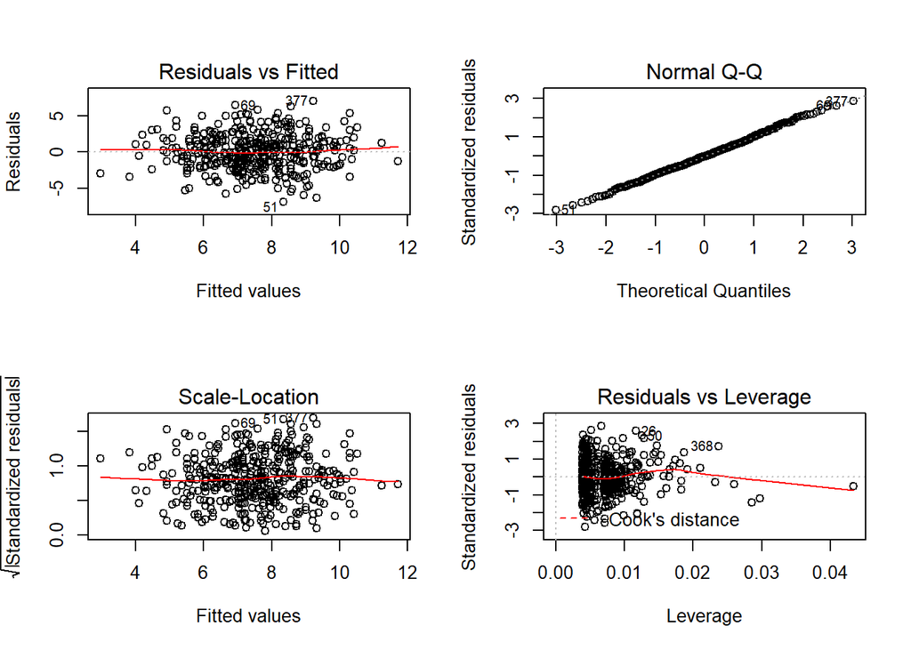

```r
par(mfrow = c(2, 2))
plot(lm5)
```

From the standardized residuals versus leverage plot we can see that there are values that are outside of the boundary of 2 and -2. So there exist outliers in the data. We can also see that there is a point that stays in on the very right side of the leverage scale, this means that our data also has a leverage point.

# 3.7.14

## (a).

```r
set.seed(1)
x1=runif (100)
x2=0.5*x1+rnorm (100)/10
y=2+2*x1+0.3*x2+rnorm (100)
```

The form of the linear model is:

$$Y = 2 +2X_{1} +0.3X_{2} + \epsilon$$

The regression coefficients are 2, 2 and 0.3.

## (b).

```r
cor(x1, x2)
```

```
## [1] 0.8351212
```

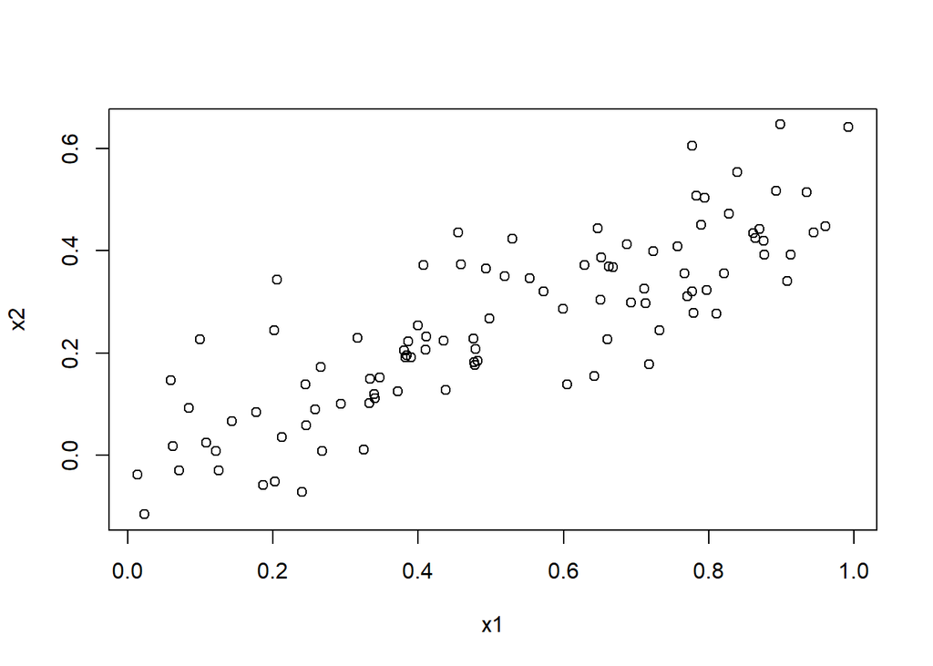

```r
plot(x1, x2)
```

The correlation coefficient is 0.8351212 and also from the scatter plot we can see that there is a linear trend between $X_{1}$ and $X_{2}$. So $X_{1}$ and $X_{2}$ are highly correlated.

## (c).

```r
fit1 <- lm(y ~ x1 + x2)
summary(fit1)
```

```
##
## Call:
## lm(formula = y ~ x1 + x2)
##
## Residuals:
##     Min      1Q  Median      3Q     Max
## -2.8311 -0.7273 -0.0537  0.6338  2.3359
##
## Coefficients:
##             Estimate Std. Error t value Pr(>|t|)
## (Intercept)   2.1305     0.2319   9.188 7.61e-15 ***
## x1            1.4396     0.7212   1.996   0.0487 *
## x2            1.0097     1.1337   0.891   0.3754
## ---
## Signif. codes:  0 '***' 0.001 '**' 0.01 '*' 0.05 '.' 0.1 ' ' 1
##
## Residual standard error: 1.056 on 97 degrees of freedom
## Multiple R-squared:  0.2088, Adjusted R-squared:  0.1925
## F-statistic:  12.8 on 2 and 97 DF,  p-value: 1.164e-05
```

In regression model:

$\beta_{0} = 2.1305$

$\beta_{1} = 1.4396$

$\beta_{2} = 1.0097$

True value:

$\beta_{0} = 2$

$\beta_{1} = 2$

$\beta_{2} = 0.3$